# Лабораторная работа №9

Управление SELinux

Ришард Когенгар

Российский университет дружбы народов, Москва, Россия

20 января 2026

# Цель работы

## Основная цель

Получить практические навыки администрирования SELinux:  
- управление режимами работы; - настройка контекстов безопасности; - использование boolean-переключателей; - диагностика проблем доступа.

# Ход выполнения работы

## Переключение режимов SELinux

- Проверка режима работы
- Перевод SELinux в разрешающий режим
- Анализ поведения системы
- Возврат в принудительный режим

Режим **permissive** используется для диагностики и отладки.

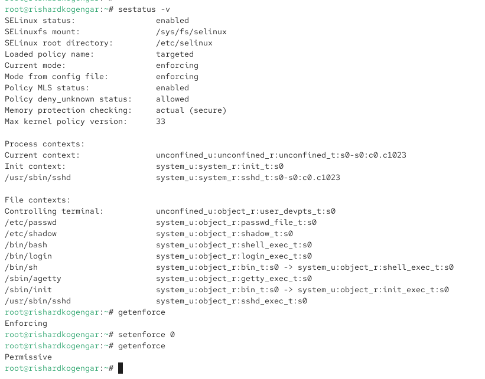

Переключение SELinux

## Полное отключение SELinux

- Изменение конфигурационного файла
- Установка режима disabled
- Перезагрузка системы
- Проверка состояния после загрузки

Переключение режимов невозможно при отключённом SELinux.

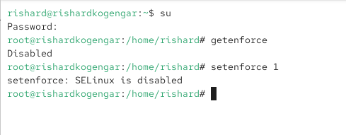

SELinux отключён

## Возврат SELinux в enforcing

- Изменение параметра SELINUX
- Перезагрузка системы
- Автоматическая перемаркировка файлов
- Проверка статуса после загрузки

Система вернулась в безопасный режим enforcing.

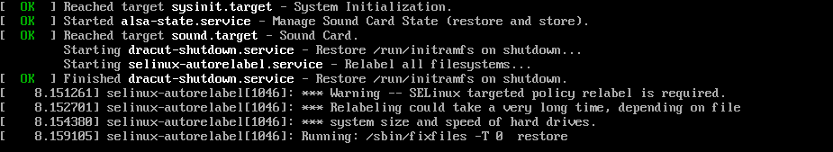

Автоперемаркировка SELinux

## Проверка контекста файлов

- Анализ контекста файла `/etc/hosts`
- Копирование файла в домашний каталог
- Изменение контекста при копировании

Контекст изменяется, так как файл считается новым объектом.

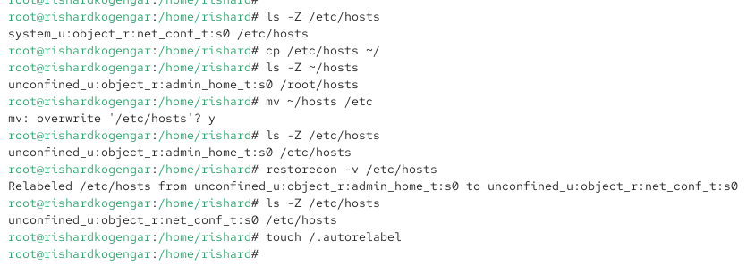

Контекст /etc/hosts

## Восстановление контекста с restorecon

- Перезапись файла с неверным контекстом
- Восстановление контекста безопасности
- Проверка результата

Контекст успешно возвращён к `net_conf_t`.

[figure not shown]

restorecon

## Подготовка веб-сервера

- Установка Apache и lynx
- Создание каталога `/web`
- Создание пользовательской страницы
- Изменение DocumentRoot

Используется нестандартный каталог для контента.

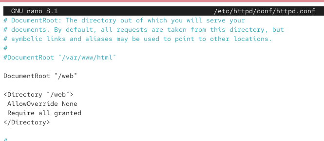

Конфигурация Apache

## Проблема доступа SELinux

- Запуск веб-сервера
- Проверка доступа через lynx
- Отображение стандартной страницы Apache

SELinux блокирует доступ к `/web`.

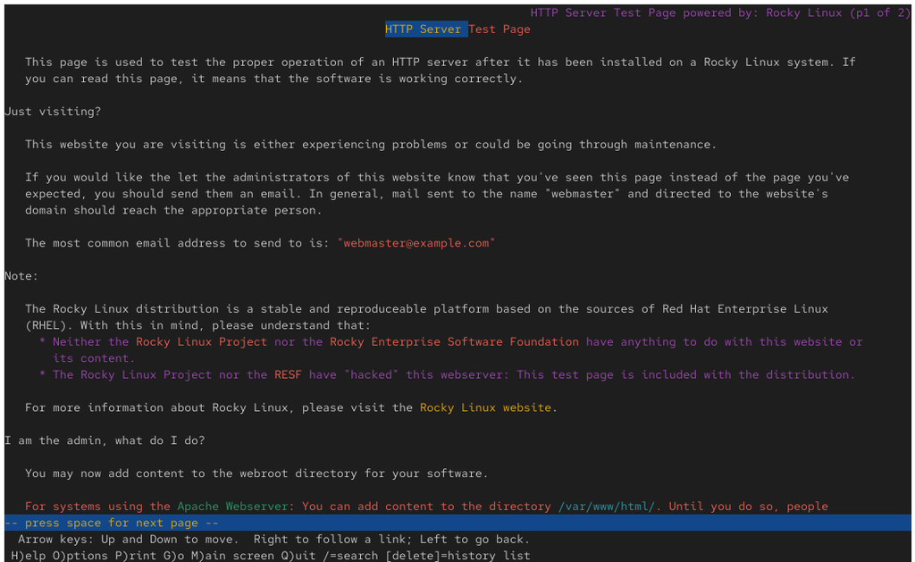

Стандартная страница Apache

## Настройка контекста для /web

- Назначение контекста `httpd_sys_content_t`
- Восстановление контекстов
- Повторная проверка доступа

Apache получил доступ к пользовательскому контенту.

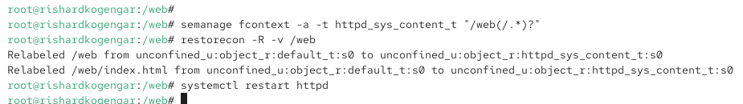

Контекст для /web

## Результат настройки

- Проверка через lynx
- Отображение пользовательской страницы
- Подтверждение корректной работы

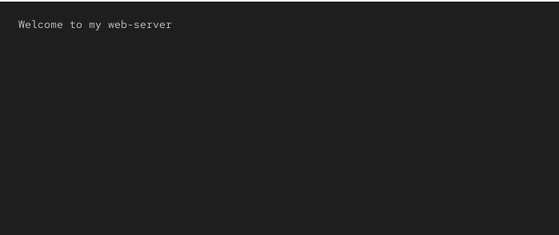

Пользовательская страница

## Постоянная настройка переключателя

- Включение boolean-переключателя постоянно
- Проверка временного и постоянного состояния
- Анализ результата

Переключатель включён полностью.

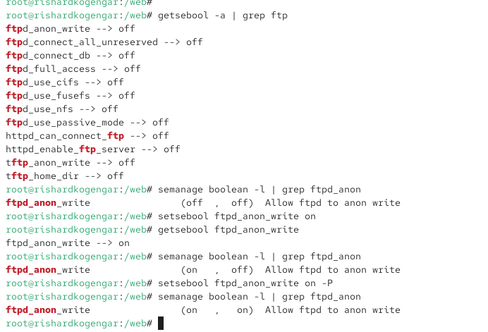

SELinux booleans

# Итоги работы

## Вывод

- Изучены режимы работы SELinux
- Освоена работа с контекстами безопасности
- Настроен доступ Apache к нестандартному каталогу
- Рассмотрены boolean-переключатели SELinux